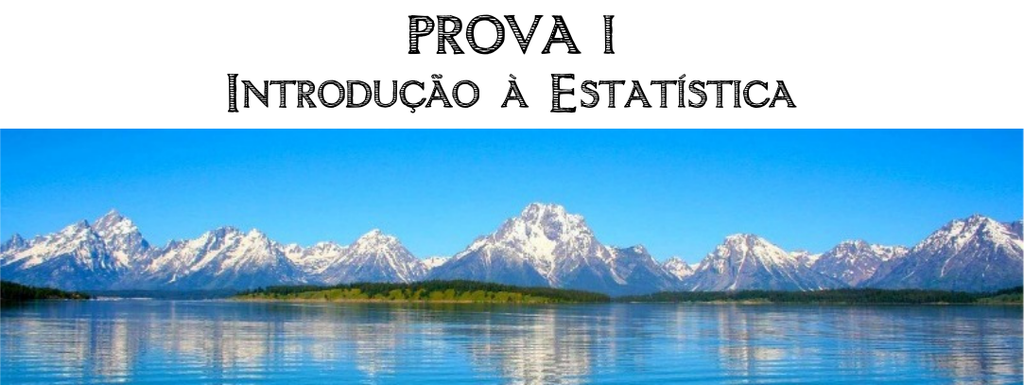

## Informações Relevantes

Usaremos duas bases de dados reais para realização dessa prova.

As bases de dados serão retiradas de nosso repositório do GitHub e do *site* brasil.io.

Faça o *download* dos seguintes conjuntos de dados:

1. [Cursos e notas de corte do PROUNI 2018](https://drive.google.com/u/0/uc?id=1lnqYHylEWT8cN6vPZ-NRR8KfFAPNq43r&export=download)
2. [Gapminder](https://downgit.evecalm.com/#/home?url=https://github.com/icaro-freire/dados_csv/blob/main/dados/csv/gapminder.csv)

O uso do *software* `R` é suficiente, mas não necessário. Ou seja, você pode usar qualquer outro *software* que estiver mais familiarizado, todavia, as dicas que serão dadas em algumas questões abaixo, serão voltadas para os usuários do `R`.

Por uma questão de organização, num crie seu projeto num diretório por nome `prova1` e organize seus dados assim (é só uma sugestão):

```r
prova1/
├── dados/
│   ├── gapminder.csv
│   └── cursos-prouni.csv
├── R/
│   ├── script_gapminder.R
│   └── script_prouni.R
├── img/
│   └── titulo_intimacy.png
└── prova_seu-nome.Rmd
```

1. No diretório `dados/`, salve os *datasets* que usaremos;
2. O diretório `R/` é opcional, mas pode servir para *scripts* de testes; ou seja, você pode fazer os testes para responder as questões separadamente. Então, assim que estiver satisfeito com as respostas (dos códigos) pode inserí-los no arquivo principal (`.Rmd`)
3. Note que, a figura `titulo_intimacy.png` deve estar salva no diretório `img/`. Também é aconselhável colocar nesse diretório qualquer figura que for usar nas suas respostas (caso use alguma fora dos códigos em R);
4. O arquivo `prova_seu-nome.Rmd` é o arquivo principal. Nele você faz a “compilação” com o `knit` para `.html`. Você só me entregará o arquivo final, em `html`.

## Identificação

**Aluno:** Coloque seu nome aqui!  
**Data:** (31/05/2023)

## Questões

```r
# importe os dados aqui (read_csv)
## importando os dados do Prouni
notas_cursos <- readr::read_csv("dados/cursos-prouni.csv")
dados_gapminder <- readr::read_csv("dados/gapminder.csv")
```

### I. Sobre o *dataset* `gapminder.csv`

**Questão 01.** Responda aos itens abaixo, mostrando como chegou nas respostas.

1. Quantas variáveis e quantas observações existem nesse conjunto de dados?
2. Indentifique os tipos de variáveis (qualitativas vs quantitativas; e suas subdivisões: nominal ou ordinal, discreta ou contínua)

**Questão 02.** Quantos países existem em cada continente? Ou seja, após agrupar por `continente`; exiba (distintamtente) a variável `pais` ; e, conte-os.

**Questão 03.** Exclua o continente que possui a menor quantidade de países e faça o gráfico de `densidade` da variável `expectativa_de_via`, colocando uma transparência de 70% no argumento da densidade (`alpha = 0.7`). Qual sua interpretação para esse gráfico?

**Questão 04.** Vamos investigar o contraste entre a relação da *expectativa de vida* e o *pib per capita* durante um intervalo de 50 anos (1957 até 2007). Para tanto, construiremos um gráfico de pontos que possui algumas características: o tamanho do ponto relaciona-se ao tamanho da população; e, a cor do ponto realaciona-se com o continente.

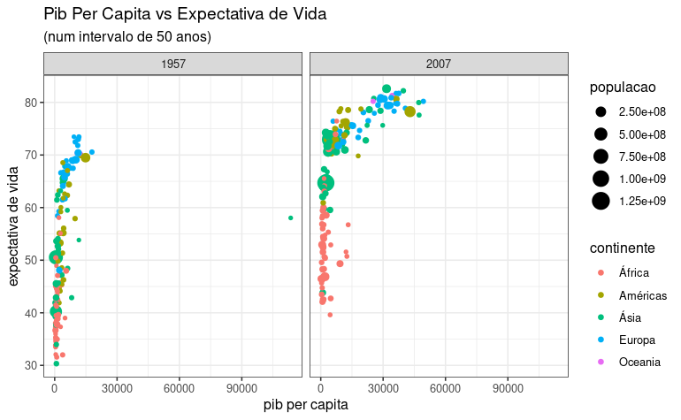

Observe que, em 1957, há um país da Ásia que possui um alto *pib per capita*, embora possua uma expectativa de vida inferior aos 60 anos. Esse alto *pib* acabou por “aglutinar” os dos outros países. Então, para uma melhor percepção dessas diferenças, mudaremos a escala do PIB (usaremos a escala logarítima):

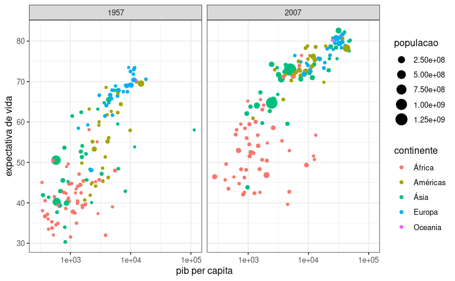

1. O que você pode afirmar, de uma forma geral e apenas observando o gráfico, sobre a expectavida de vida dos continentes? Ela aumentou ou diminuiu ao longo desses 50 anos em questão?
2. Em 1957, qual país da Ásia possuia o maior PIB *per capita*? E, nesse mesmo ano, qual possuía a maior expectativa de vida?
3. Em 2007, encontre a expectativa de vida e o pib *per capita* dos dois países do item (b). O que aconteceu?
4. Quais são os dois países com maior população (maior diâmetro do ponto) em 1957 e em 2007? O que aconteceu com o pib per capita e a expectativa de vida deles em 50 anos?
5. Faça um gráfico de pontos relacionando *pib per capita* e *expectativa de vida* durante todos os anos do dataset. Coloque uma reta de regressão nesses dados e responda se há uma tendência positiva ou negativa entre essas variáveis. Use uma escala logarítimica no eixo x (para isso, basta adicionar `scale_x_log10()` à camada do `ggplot()`).

**Questão 05.** As seguintes perguntas estão relacionadas ao continente Africano.

1. Encontre os países com menor e maior expectativa de vida no ano de 1952. Chame o primeiro de `pais_menor` e o segundo de `pais_maior`. São os mesmos em 2007?
2. O seguinte conjunto de códigos produz um gráfico de linhas relacionando a expectativa de vida ao longo dos anos, dos países `pais_menor` e `pais_maior`. Substitua os nomes adequados e responda: os gráficos são semelhantes?

```r
dados_gapminder |>
  filter(pais %in% c("pais_menor", "pais_maior")) |>
  ggplot() +
  aes(x = ano, y = expectativa_de_vida, color = pais, group = pais) +
  geom_line() +
  labs(
    x = "",
    y = ""
  ) +
  theme_minimal()
```

**Questão 06.** No gráfico da questão anterior, do `pais_menor`, há uma queda vertiginosa, na década de 90, da expectativa de vida. Pesquise sobre o que poderia ter ocasionado tal queda.